# Lab 07: Linear Regression

# Permissions and IAM roles

This assignment assumes that you are running RStudio on an Amazon EC2 instance created from AMI `FIN550-RStudio` and IAM role `BigDataEC2Role`.

In this assignment, you will transfer files between your EC2 instance and S3 using file commands from the [AWS Command Line Interface (CLI)](https://aws.amazon.com/cli/#file_commands_anchor). When a file request is made to an S3 bucket, AWS checks to see if the request is coming from an account that is authorized to make the file request. The class S3 bucket at `s3://bigdata-fin550-league` can only be accessed by AWS EC2 instances with the IAM role `BigDataEC2Role` attached. You will also be able to access S3 buckets that you create, such as `s3://fin550-assignments-netid`.

To confirm that the IAM role `BigDataEC2Role` is correctly attached, select your instance from the Amazon EC2 Console. You should see the role listed under the Description tab.

# Lab workflow

Create a folder for today’s lab. In the RStudio File window, create a New Folder under your home directory at `~/fin550/lab-07`. Copy the file `lab-07.Rmd` from the course S3 lab repository at `s3://bigdata-fin550-league` to your `lab-07` folder by entering the following Unix command. RStudio allows you to execute operating system commands using the built-in shell, found at `Tools` > `Shell`.

```bash
# This is a Unix command. Enter via RStudio Shell
aws s3 cp --recursive s3://bigdata-fin550-league/lab-07 ~/fin550/lab-07
```

Navigate to the `~/fin550/lab-07` lab directory, and open the assignment template `lab-07.Rmd`. Edit the template to answer the questions and complete the assignment.

# Predicting Home Sale Prices

The file **ameshousing.csv** contains sale prices and home characteristics of 300 homes located in Ames, Iowa from 2006 to 2010.

In lecture 7, we ran a simple linear regression of sale prices (`SalePrice`) on the above ground living area (`Gr_Liv_Area`), where `Gr_Liv_Area` is a continuous numeric variable.

In this assignment, we will transform `Gr_Liv_Area` to a categorical variable and then fit a simple linear regression of `SalePrice` on bins of `Gr_Liv_Area`.

## 0 Load the packages and suppress scientific notation

Use `library()` to load `ggplot2`. Use `options(scipen=999)` to suppress scientific notation.

## 1 Create a data frame

Load the data with `read_csv()` and save the result in a data frame named `housing.df`. Return the first six rows and column names using `head()` and `names()`, respectively.

## 2 Identify thresholds of four bins that have an equal number of observations

To create four bins that have an equal number of observations in each bin, we need to use function `quantile()` to identify five thresholds: the minimum value (0 quartile), the first quartile, the second quartile (median), and the third quartile, and the maximum value (fourth quartile).

The first parameter in function `quantile()` is the variable’s name, `housing.df$Gr_Liv_Area`. The second parameter is a vector of probabilities. For example, use 0.5 to represent the second quartile, because 50% of data lies below this value.

Hint: use `probs = c(0,0.25,0.5,0.75,1)` to return the minimum value (0 quartile), the first quartile, the second quartile (median), and the third quartile, and the maximum value (fourth quartile).

Save the result as `bins`.

## 3 Bin `Gr_Liv_Area`

To transform a continuous variable into a categorical variable, use function `.bincode()` to bin `Gr_Liv_Area` according to the thresholds found in question 2.

The first parameter in function `.bincode()` is the variable’s name, `housing.df$Gr_Liv_Area`. The second parameter specifies the cut points, which should be bins without names. Use `include.lowest = TRUE` as the third parameter to include the lowest value, 334, in the first bin.

Hint: `unname(bins)` removes the names of a named vector. For example, `bins <- unname(bins)` returns the values only.

Save the binned above ground living area as `Gr_Liv_Area_bin` in `housing.df`. It takes a value of 1 if `Gr_Liv_Area` is in [334, 952], a value of 2 if `Gr_Liv_Area` is in (952, 1135], a value of 3 if `Gr_Liv_Area` is in (1135, 1337.25], and a value of 4 if `Gr_Liv_Area` is in (1337.25, 1500].

Use `head()` and `str()` to return the first six values and the data type of `Gr_Liv_Area_bin`.

## 4 Fit a linear regression model with an ordinal categorical predictor

Use `lm()` to fit a linear regression model with an ordinal categorical predictor, `Gr_Liv_Area_bin`.

`Gr_Liv_Area_bin` should be treated as an ordinal categorical variable, where the order matters but not the difference between values. For example, the difference between `Gr_Liv_Area` categories [334, 952] and (952, 1135] does not have the same meaning as the difference between `Gr_Liv_Area` categories (952, 1135] and (1135, 1337.25].

Hint: `as.factor()` converts `Gr_Liv_Area_bin` into a categorical variable in the regression. Thus, use `formular SalePrice ~ as.factor(Gr_Liv_Area_bin)` in `lm()`.

Save the regression model as `lm` and return `summary(lm)`.

## 5 Calculate the mean of `SalePrice` for each value in `Gr_Liv_Area_bin`

Calculate the mean of `SalePrice` for each value in `Gr_Liv_Area_bin`.

What is the mean of `SalePrice` for homes where `Gr_Liv_Area_bin` is equal to 2 (category 2)? What is the mean of `SalePrice` for homes where `Gr_Liv_Area_bin` is equal to 1 (category 1)? What is the group mean difference between category 2 and category 1?

What is the mean of `SalePrice` for homes where `Gr_Liv_Area_bin` is equal to 3 (category 3)? What is the group mean difference between category 3 and category 1?

What is the mean of `SalePrice` for homes where `Gr_Liv_Area_bin` is equal to 4 (category 4)? What is the group mean difference between category 4 and category 1?

Notice that the regression coefficients are group mean differences relative to the omitted category (category 1).

## 6 Plot the mean of `SalePrice` for each value in `Gr_Liv_Area_bin`

Use `ggplot()` to plot the mean of `SalePrice` for each value in `Gr_Liv_Area_bin`.

The plot looks like the following graph.

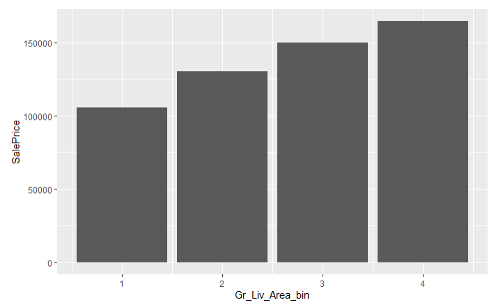

# Assignment submission

After completing the assignment, you should have two files in your`~/fin550/lab-07` lab directory: the Markdown file `lab-07.Rmd` and the corresponding output file `lab-07.html`. Upload both of these files to your S3 assignments bucket, in a folder called `lab-07`. Running the following S3 file command from the Shell in RStudio will automatically created the `lab-07` folder when uploading the respective files (change `netid` to your own). You can navigate to the S3 Management Console in your browser to confirm that the upload was successful.

```bash
# This is a Unix command. Enter via RStudio Shell
# **IMPORTANT** Replace <netid> with your netid before running the following command
aws s3 cp --recursive ~/fin550/lab-07 s3://fin550-assignments-<netid>/lab-07
```